# act_report

```python
import matplotlib.pyplot as plt
from IPython import display
from IPython.display import Image
from IPython.core.display import HTML
```

## An inside look into the WeRateDogs Twitter Account

This is a brief summary of the insights gained from an anlaysis of the WeRateDogs Twitter account. WeRateDogs is a twitter account that rate's people dogs with a humorous comment about the dog.

#### Ratings Distribution

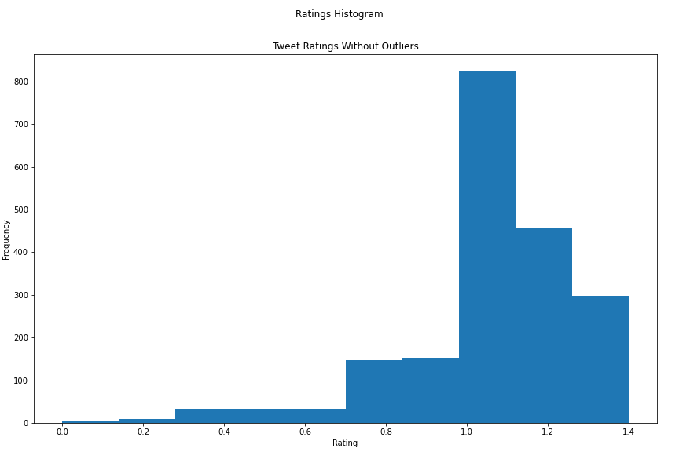

The boxplot below shows that ratings range from 0.8 to 1.4 with the majority of ratings falling between 1 and 1.2.

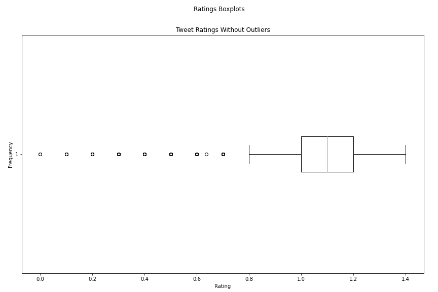

#### Highest Rated Dog Breed

Filtering ratings by dog breed provided some interesting observations. The bar chart below measures the highest rated dog breed based on average rating. What is in interesting here is that our highest rated "breed" in this case shows up as "unidentifiable".

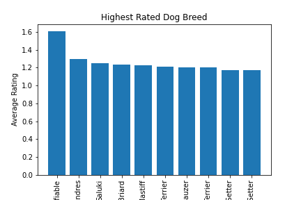

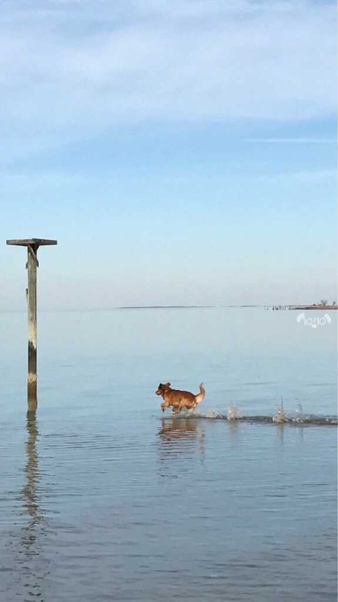

```python
Lakedog_Url= ("https://pbs.twimg.com/media/DAClmHkXcAA1kSv.jpg")
Image(Lakedog_Url)
```

Other times cells were filled "unidentifiable" when there were multiple pictures for the same dog as shown below.

[figure not shown]

And sometimes, cells were filled "unidentifiable" when there were no dogs in the picture at all! Lol

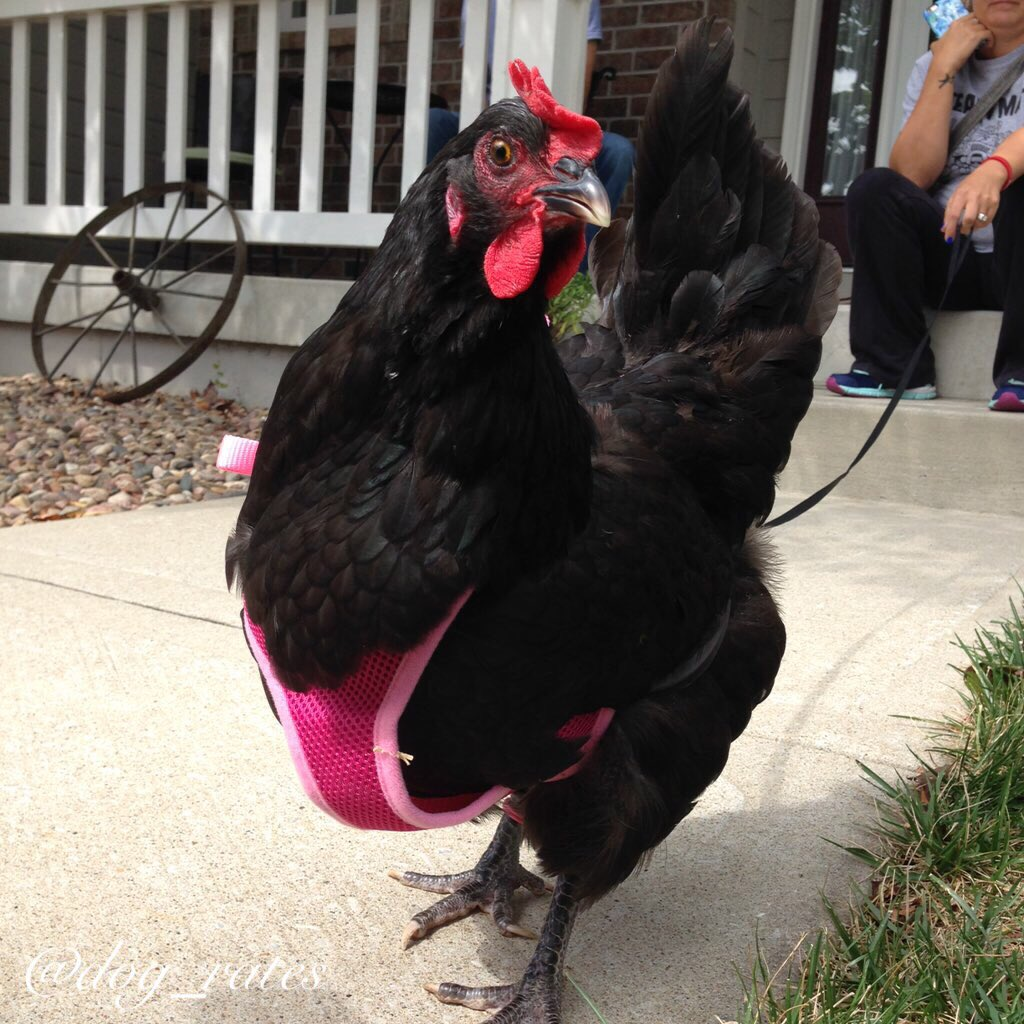

```python
Rooster_Url= ("https://pbs.twimg.com/media/CVHEju0XAAEUZRY.jpg")
Image(Rooster_Url)
```

Because the variable is so prevalent in our dataset, an interesting study would be to analyze the "unidentifiable" entries and see if there are any other common themes within the pictures. For example, are any of the dogs wearing the same piece of clothing or accessory? Or are any certain locations such as the beach or a car more common? Back to our bar chart, Bouvier Des Flandres, Saluki, and Briard show to be the top 3 highest ranking canine breeds.

#### Dog Stages

Along with a unique rating system, WeRateDogs categorizes canines in separate dog stages based on the age and life stage of the dogs. The stages in order from youngest to oldest are pupper, puppo, doggo, and fluffer. There are various metrics I could have used to measure which life stage was most popular. In the chart below, I used the amount of times the original tweet was retweeted which is the ultimate compliment that someone would like the tweet enough to retweet it to their own friends and colleagues.

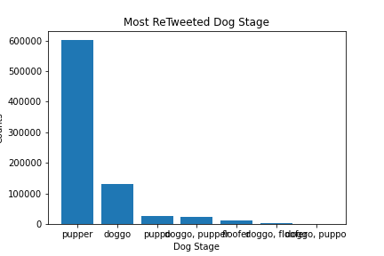

Unsurprisingly, puppies, or dogs in the the "pupper" stage were by far and away the tweets that were retweeted the most with 602,196 retweets. Coming in a distant second, tweets with dogs in the "doggo" stage were retweeted 130,797 times. This is a clear indication that tweets with dogs in the "pupper" stage were most popular among WeRateDogs users.

#### Most Favored Tweet

[figure not shown]

#### Most Common Dog Names

Finally, speaking of dog names, the chart below displays the most common dog names in the WeRateDogs twitter account. The name Charlie showed up 11 times in the data. Followed by the names Oliver, Cooper, and Lucy which were found 10 times in the data.

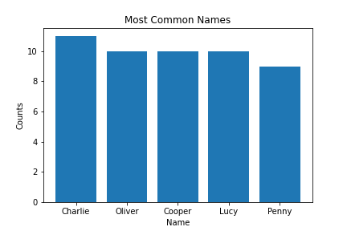

[figure not shown]